# Sleep health and lifestyle

#### By : Mohammed BENHADJ

# Introduction

Sleep is a fundamental aspect of human well-being, playing a crucial role in physical and mental health. Understanding the factors that influence sleep patterns and overall lifestyle can provide valuable insights into promoting healthier living. The Sleep Health and Lifestyle dataset under consideration comprises a comprehensive collection of information related to individuals' sleep habits, daily activities, and various lifestyle factors. This dataset offers a multifaceted view of contributors to sleep quality, duration, and associated health indicators.

**Objective:**

The primary objective of analyzing this dataset is to uncover patterns, correlations, and potential factors influencing sleep health and lifestyle. By examining relationships between variables such as sleep duration, quality of sleep, physical activity and stress levels.

#### Importing Essential Modules:

```python
import pandas as pd
import matplotlib.pyplot as plt
import seaborn as sns
```

#### Upload the dataset:

```python
df=pd.read_csv("Sleep_health_and_lifestyle_dataset2.csv")
df.head()
```

|  | Person ID | Gender | Age | Occupation | Sleep Duration | Quality of Sleep | Physical Activity Level | Stress Level | BMI Category | Heart Rate | Daily Steps | Sleep Disorder |
| --- | --- | --- | --- | --- | --- | --- | --- | --- | --- | --- | --- | --- |
| 0 | 1 | Male | 27 | Software Engineer | 6.1 | 6 | 42 | 6 | Overweight | 77 | 4200 | NaN |
| 1 | 2 | Male | 28 | Doctor | 6.2 | 6 | 60 | 8 | Normal | 75 | 10000 | NaN |
| 2 | 3 | Male | 28 | Doctor | 6.2 | 6 | 60 | 8 | Normal | 75 | 10000 | NaN |
| 3 | 4 | Male | 28 | Sales Representative | 5.9 | 4 | 30 | 8 | Obese | 85 | 3000 | Sleep Apnea |
| 4 | 5 | Male | 28 | Sales Representative | 5.9 | 4 | 30 | 8 | Obese | 85 | 3000 | Sleep Apnea |

## check missing values

```python
df.isna().sum()
```

```
Person ID                    0
Gender                       0
Age                          0
Occupation                   0
Sleep Duration               0
Quality of Sleep             0
Physical Activity Level      0
Stress Level                 0
BMI Category                 0
Heart Rate                   0
Daily Steps                  0
Sleep Disorder             219
dtype: int64
```

#### Fill the null values of Sleep disorder by 'None'

```python
df['Sleep Disorder'] = df['Sleep Disorder'].fillna('None')
df.head()
```

|  | Person ID | Gender | Age | Occupation | Sleep Duration | Quality of Sleep | Physical Activity Level | Stress Level | BMI Category | Heart Rate | Daily Steps | Sleep Disorder |
| --- | --- | --- | --- | --- | --- | --- | --- | --- | --- | --- | --- | --- |
| 0 | 1 | Male | 27 | Software Engineer | 6.1 | 6 | 42 | 6 | Overweight | 77 | 4200 | None |
| 1 | 2 | Male | 28 | Doctor | 6.2 | 6 | 60 | 8 | Normal | 75 | 10000 | None |
| 2 | 3 | Male | 28 | Doctor | 6.2 | 6 | 60 | 8 | Normal | 75 | 10000 | None |
| 3 | 4 | Male | 28 | Sales Representative | 5.9 | 4 | 30 | 8 | Obese | 85 | 3000 | Sleep Apnea |
| 4 | 5 | Male | 28 | Sales Representative | 5.9 | 4 | 30 | 8 | Obese | 85 | 3000 | Sleep Apnea |

## Dimension of dataset :

```python
df.shape
```

```
(374, 12)
```

## Description about columns :

```python
df.describe()
```

|  | Person ID | Age | Sleep Duration | Quality of Sleep | Physical Activity Level | Stress Level | Heart Rate | Daily Steps |
| --- | --- | --- | --- | --- | --- | --- | --- | --- |
| count | 374.000000 | 374.000000 | 374.000000 | 374.000000 | 374.000000 | 374.000000 | 374.000000 | 374.000000 |
| mean | 187.500000 | 42.184492 | 7.132086 | 7.312834 | 59.171123 | 5.385027 | 70.165775 | 6816.844920 |
| std | 108.108742 | 8.673133 | 0.795657 | 1.196956 | 20.830804 | 1.774526 | 4.135676 | 1617.915679 |
| min | 1.000000 | 27.000000 | 5.800000 | 4.000000 | 30.000000 | 3.000000 | 65.000000 | 3000.000000 |
| 25% | 94.250000 | 35.250000 | 6.400000 | 6.000000 | 45.000000 | 4.000000 | 68.000000 | 5600.000000 |
| 50% | 187.500000 | 43.000000 | 7.200000 | 7.000000 | 60.000000 | 5.000000 | 70.000000 | 7000.000000 |
| 75% | 280.750000 | 50.000000 | 7.800000 | 8.000000 | 75.000000 | 7.000000 | 72.000000 | 8000.000000 |
| max | 374.000000 | 59.000000 | 8.500000 | 9.000000 | 90.000000 | 8.000000 | 86.000000 | 10000.000000 |

```python
df.info()
```

```
<class 'pandas.core.frame.DataFrame'>
RangeIndex: 374 entries, 0 to 373
Data columns (total 12 columns):
 #   Column                   Non-Null Count  Dtype
---  ------                   --------------  -----
 0   Person ID                374 non-null    int64
 1   Gender                   374 non-null    object
 2   Age                      374 non-null    int64
 3   Occupation               374 non-null    object
 4   Sleep Duration           374 non-null    float64
 5   Quality of Sleep         374 non-null    int64
 6   Physical Activity Level  374 non-null    int64
 7   Stress Level             374 non-null    int64
 8   BMI Category             374 non-null    object
 9   Heart Rate               374 non-null    int64
 10  Daily Steps              374 non-null    int64
 11  Sleep Disorder           374 non-null    object
dtypes: float64(1), int64(7), object(4)
memory usage: 35.2+ KB
```

#### Difference of Gender :

```
189 Male
185 Famele
```

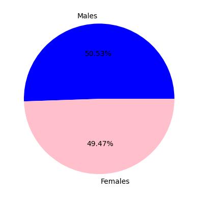

```python
males=df[df.Gender=="Male"]
Females=df[df.Gender=="Female"]
print(f"""
{len(males)} Male
{len(Females)} Famele
""")
plt.pie([len(males), len(Females)], autopct="%.2f%%", labels=["Males", "Females"], colors=["blue","pink"])
plt.show()
```

#### Distribution of sleep disorders in the data :

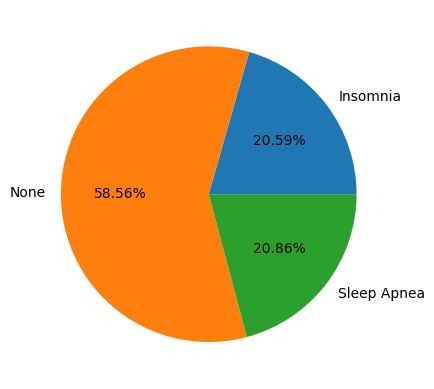

```python
disorder=df.groupby("Sleep Disorder").size()
disorder.plot(kind="pie", autopct="%.2f%%")
plt.show()
```

**Insomnia :** Insomnia is a sleep disorder characterized by difficulty falling asleep or staying asleep, even when a person has the opportunity for a full night's sleep

**Sleep apnea :** Sleep apnea is a condition where you stop breathing while you're asleep, it happens because something is blocking your airway when you're sleeping, making it hard to breathe.

**None :** When a person has no sleep disorder, it means they are able to fall asleep and stay asleep without any significant problems.

## Gender Distribution for Various Sleep Disorders :

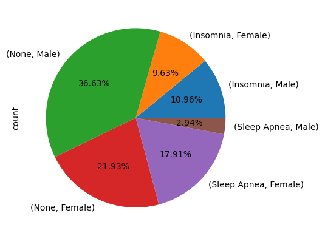

```python
disorder=df.groupby("Sleep Disorder")["Gender"].value_counts()
disorder.plot(kind="pie", autopct="%.2f%%")
plt.xticks(rotation=45)
plt.show()
```

that figure display individuals that has no sleep disorder represent 36% males and 22% Females.

### Distribution of Quality by duration of sleep

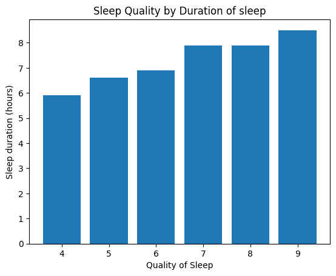

```python
plt.bar(df["Quality of Sleep"],df["Sleep Duration"])
plt.xlabel("Quality of Sleep")
plt.ylabel("Sleep duration (hours)")
plt.title("Sleep Quality by Duration of sleep")
plt.show()
```

while sleep duration is rising while the quality of sleep is going to be good

The top three sleep quality ratings between 7 and 9 are associated with sleep durations in the range of 7 to 8.5 hours.

## Relation between Sleep Duration and Stress level

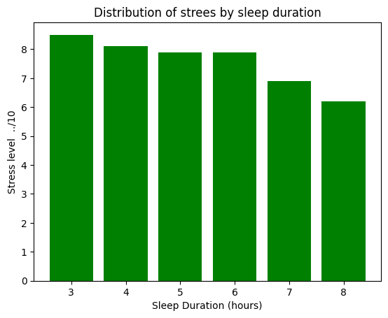

```python
plt.bar(df["Stress Level"],df["Sleep Duration"], color="green")
plt.xlabel("Sleep Duration (hours)")
plt.ylabel("Stress level  ../10")
plt.title("Distribution of strees by sleep duration")
plt.show()
```

That figure explain that while sleep duration is rising while the stress level was less

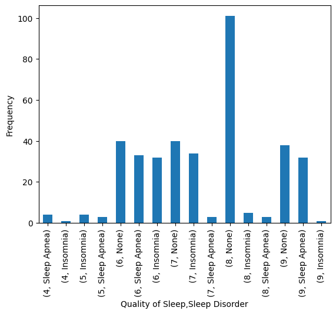

```python
df1=df.sort_values("Quality of Sleep", ascending=False)
sqs=df1.groupby("Quality of Sleep")["Sleep Disorder"].value_counts()
sqs.plot(kind="bar")
plt.ylabel('Frequency')
plt.show()
```

From that figure, the best quality of sleep that give a normal sleep (no sleep disorder) is 8.

# Distribution of BMI Categories

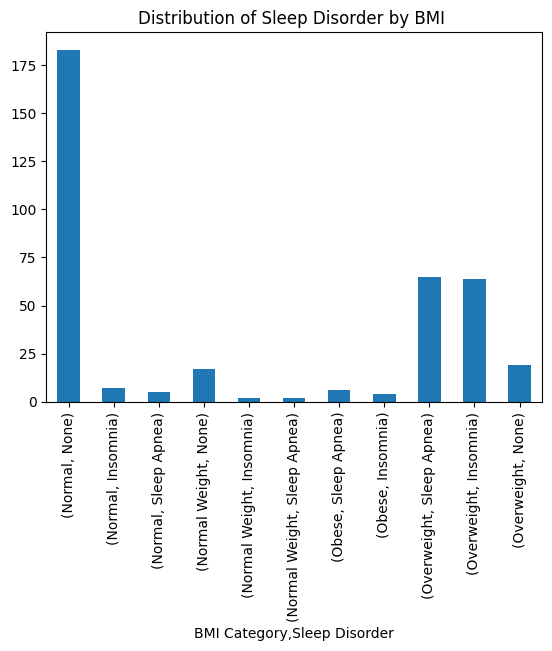

```python
dfd=df.groupby("BMI Category")["Sleep Disorder"].value_counts()
dfd.plot(kind="bar")
plt.title("Distribution of Sleep Disorder by BMI ")
plt.show()
```

More than 180 of individuals have a normal BMI category and has no sleep disorder

## Sleep Duration for Individuals with Normal BMI

```python
bmi=df[df["BMI Category"]=="Normal"]
min_max=bmi["Sleep Duration"].agg(["max", "min"])
print(f"""
People who have Normal BMI sleep : {min_max.iloc[0]}h as max hours of sleep, and {min_max.iloc[1]}h as min hours of sleep.
    """)
```

```
People who have Normal BMI sleep : 8.5h as max hours of sleep, and 6.0h as min hours of sleep.
```

## Relationship Between Stress Level and Physical Activity Level

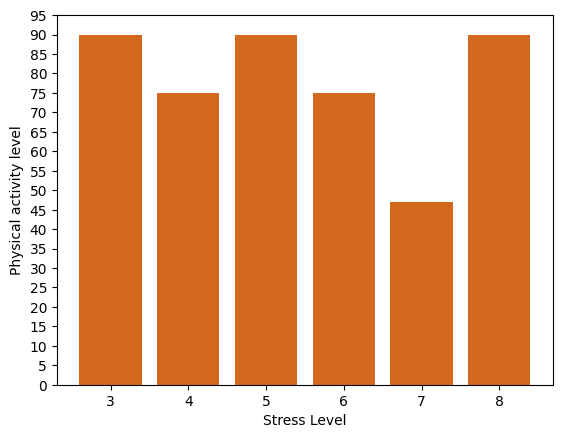

```python
plt.bar(df["Stress Level"], df["Physical Activity Level"], color="chocolate")
plt.yticks([i for i in range(0,100,5)])
plt.xlabel("Stress Level")
plt.ylabel("Physical activity level")
plt.show()
```

### Average Age Comparison by Sleep Disorde

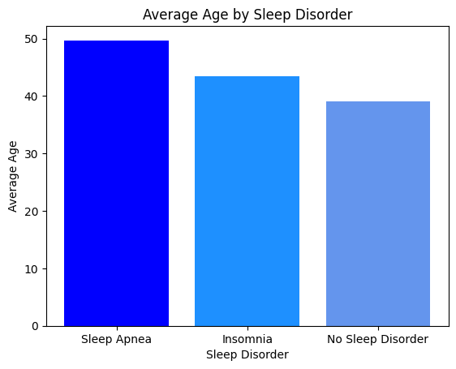

```python
sleep_apnea = df[df['Sleep Disorder'] == 'Sleep Apnea']
insomnia = df[df['Sleep Disorder'] == 'Insomnia']
none = df[df['Sleep Disorder'] == 'None']

avg_age_sleep_apnea = sleep_apnea['Age'].mean()
avg_age_insomnia = insomnia['Age'].mean()
avg_age_none = none['Age'].mean()

sleep_disorders = ['Sleep Apnea', 'Insomnia', 'No Sleep Disorder']
average_ages = [avg_age_sleep_apnea, avg_age_insomnia, avg_age_none]
plt.bar(sleep_disorders, average_ages, color=['blue', 'dodgerblue', 'cornflowerblue'])
plt.title('Average Age by Sleep Disorder')
plt.xlabel('Sleep Disorder')
plt.ylabel('Average Age')
plt.show()
```

### What is the distribution of stress levels in the dataset?

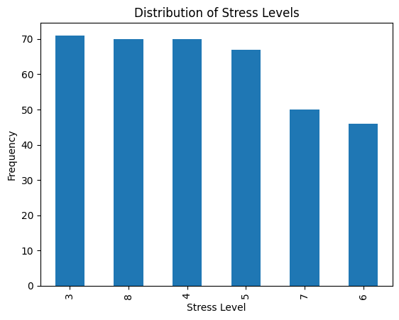

```python
stress_level_counts = df['Stress Level'].value_counts()
stress_level_counts.plot(kind='bar')
plt.xlabel('Stress Level')
plt.ylabel('Frequency')
plt.title('Distribution of Stress Levels')
plt.show()
```

### Gender-based Analysis of Sleep Duration:

```python
mean_duration_by_gender = df.groupby('Gender')['Sleep Duration'].mean()

mean_male_duration = mean_duration_by_gender['Male']

mean_female_duration = mean_duration_by_gender['Female']

print("Mean Sleep Duration for Males:", mean_male_duration)
print()
print("Mean Sleep Duration for Females:", mean_female_duration)
```

```
Mean Sleep Duration for Males: 7.036507936507937

Mean Sleep Duration for Females: 7.22972972972973
```

These statistics show that, females sleep a bit longer than males.

## Average Sleep Duration for Participants with and without Sleep Disorders

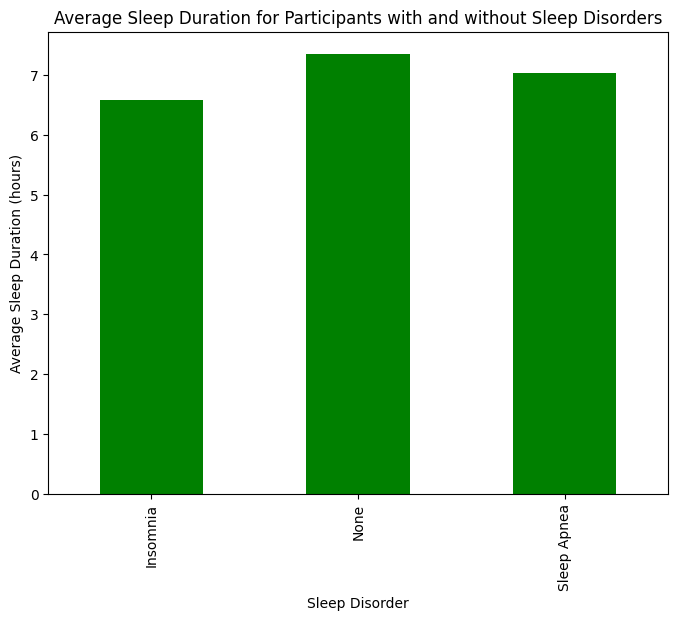

```python
avg_sleep_duration_by_sleep_disorder = df.groupby('Sleep Disorder')['Sleep Duration'].mean()
plt.figure(figsize=(8, 6))
avg_sleep_duration_by_sleep_disorder.plot(kind='bar', color='green')
plt.title('Average Sleep Duration for Participants with and without Sleep Disorders')
plt.xlabel('Sleep Disorder')
plt.ylabel('Average Sleep Duration (hours)')
plt.show()
```

## Stress Levels and Sleep Disorders

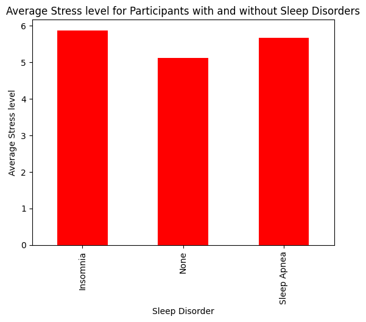

```python
avg_sleep_duration_by_sleep_disorder = df.groupby('Sleep Disorder')['Stress Level'].mean()
avg_sleep_duration_by_sleep_disorder.plot(kind='bar', color='red')
plt.title('Average Stress level for Participants with and without Sleep Disorders')
plt.xlabel('Sleep Disorder')
plt.ylabel('Average Stress level')
plt.show()
```

## Individuals without Sleep Disorder

```python
dd=df.loc[df["Sleep Disorder"]=="None"]
print(len(dd), "persons that have no sleep disorder")
```

```
219 persons that have no sleep disorder
```

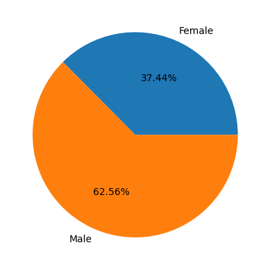

```python
dd.groupby("Gender").size().plot(kind="pie", autopct="%.2f%%")
plt.show()
```

```python
dd.groupby("BMI Category").size()
```

```
BMI Category
Normal           183
Normal Weight     17
Overweight        19
dtype: int64
```

```python
dd["Age"].mean()
```

```
39.0365296803653
```

the next cell display the average of Sleep Duration, Quality of Sleep and Stress Level

```python
print("Average Sleep duration :",dd["Sleep Duration"].mean())
print("Average Quality of sleep :",dd["Quality of Sleep"].mean())
print("Average Stress level :",dd["Stress Level"].mean())
```

```
Average Sleep duration : 7.358447488584476
Average Quality of sleep : 7.6255707762557075
Average Stress level : 5.114155251141552
```

Based on the last information, it appears that the individuals experiences a good quality of sleep (between 6 and 9), with a duration ranging between 6 and 8 hours, average of age of these individuals is 39 years and more than 62% of them are males.

# Conclusion:

Finally, after all these data i found that sleep disorder is remoted by sleep duration, quality of sleep and stress level. these factors are effected by anothers like Occupation and BMI catrgories which can changed by weight which effected by eating.

Based on the previous information, to get a good sleep without any sleep disorder, individuals should focus to get a Normal BMI category by taking healthy food and avoid unhealthy, take care on sleep duration by getting sleep early and get more than 6h of sleep, do some physical activities that give a healthy body like walking, running, go to gym or any sport need efforts especially for people who do not do any physically activities on their job like Sales Representative, scientist ...

# Data Encoding

### Initialize the features and targets

```python
X=df.drop(['Person ID', 'Sleep Disorder'], axis=1)
Y=df["Sleep Disorder"]
```

### Encoding the categorical columns

```python
cat = X.select_dtypes(include=['object'])
cat
```

|  | Gender | Occupation | BMI Category |
| --- | --- | --- | --- |
| 0 | Male | Software Engineer | Overweight |
| 1 | Male | Doctor | Normal |
| 2 | Male | Doctor | Normal |
| 3 | Male | Sales Representative | Obese |
| 4 | Male | Sales Representative | Obese |
| ... | ... | ... | ... |
| 369 | Female | Nurse | Overweight |
| 370 | Female | Nurse | Overweight |
| 371 | Female | Nurse | Overweight |
| 372 | Female | Nurse | Overweight |
| 373 | Female | Nurse | Overweight |

374 rows × 3 columns

```python
from sklearn.preprocessing import LabelEncoder
enc = LabelEncoder()
for col in cat.columns:
    X[col] = enc.fit_transform(cat[col])
```

```python
X.head()
```

|  | Gender | Age | Occupation | Sleep Duration | Quality of Sleep | Physical Activity Level | Stress Level | BMI Category | Heart Rate | Daily Steps |
| --- | --- | --- | --- | --- | --- | --- | --- | --- | --- | --- |
| 0 | 1 | 27 | 9 | 6.1 | 6 | 42 | 6 | 3 | 77 | 4200 |
| 1 | 1 | 28 | 1 | 6.2 | 6 | 60 | 8 | 0 | 75 | 10000 |
| 2 | 1 | 28 | 1 | 6.2 | 6 | 60 | 8 | 0 | 75 | 10000 |
| 3 | 1 | 28 | 6 | 5.9 | 4 | 30 | 8 | 2 | 85 | 3000 |
| 4 | 1 | 28 | 6 | 5.9 | 4 | 30 | 8 | 2 | 85 | 3000 |

# Now this Dataset is ready to use by machine learning model

## Apply a Machine learning Model

**Importing the important models and functions**

```python
from sklearn.model_selection import train_test_split
from sklearn.ensemble import RandomForestClassifier
from sklearn.metrics import accuracy_score, confusion_matrix
```

### split the dataset to training set and testing set, by giving 25% of the data to test set

```python
X_train, X_test, y_train, y_test=train_test_split(X,Y, test_size=0.25, random_state=42)
```

### Create the model

```python
model=RandomForestClassifier()
model.fit(X_train, y_train)
```

```
RandomForestClassifier()
```

### Apply prediction on the data

```python
y_pred=model.predict(X_test)
```

### Calculat the accuracy

```python
accuracy=accuracy_score(y_pred=y_pred, y_true=y_test)
print(f"RFC Accuracy : {accuracy*100}%")
```

```
RFC Accuracy : 89.36170212765957%
```

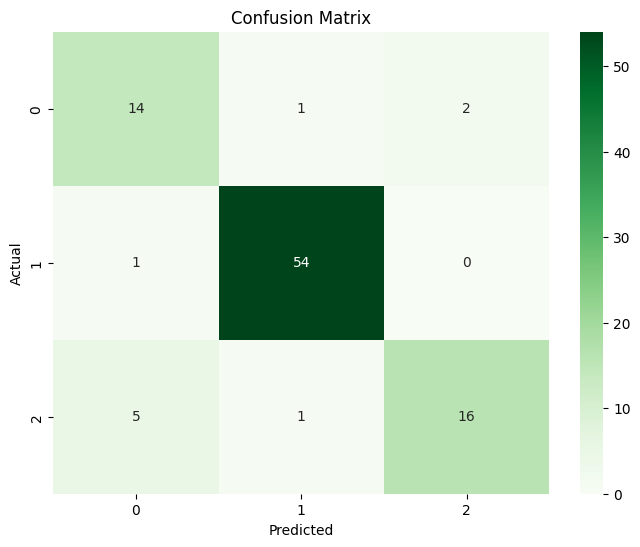

```python
cm = confusion_matrix(y_test, y_pred)
plt.figure(figsize=(8, 6))
sns.heatmap(cm, annot=True, fmt='g', cmap='Greens')
plt.xlabel('Predicted')
plt.ylabel('Actual')
plt.title('Confusion Matrix')
plt.show()
```

```python
feature_importances = model.feature_importances_

feature_importance_df = pd.DataFrame({'Feature': X.columns, 'Importance': feature_importances})
feature_importance_df = feature_importance_df.sort_values(by='Importance', ascending=False)
feature_importance_df.head()
```

|  | Feature | Importance |
| --- | --- | --- |
| 7 | BMI Category | 0.218958 |
| 1 | Age | 0.165207 |
| 2 | Occupation | 0.158338 |
| 3 | Sleep Duration | 0.111057 |
| 5 | Physical Activity Level | 0.109245 |

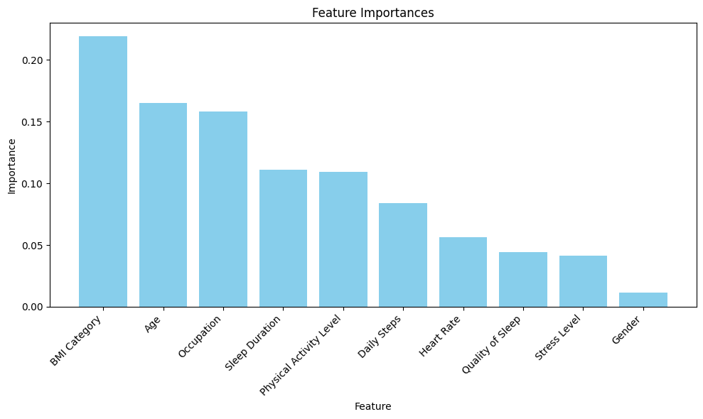

```python
plt.figure(figsize=(10, 6))
plt.bar(feature_importance_df['Feature'], feature_importance_df['Importance'], color='skyblue')
plt.xlabel('Feature')
plt.ylabel('Importance')
plt.title('Feature Importances')
plt.xticks(rotation=45, ha='right')  # Rotate x-axis labels for better readability
plt.tight_layout()  # Adjust layout to prevent clipping of labels
plt.show()
```

The important 4 features for that model are BMI cateogries, age, occupation and Sleep Duration.